# Exercises Applied Modelling in Drug Development

Bayes 2026, Leiden

Sebastian Weber

Novartis Pharma AG

Lukas Widmer

October 21, 2026

# Setup

## R Session

**Note**

All shown code can be copied by simply clicking the top right icon of the code block. The code blocks from the main presentation can also be copied by the same icon, which is visible when hovering over the respective block with your mouse.

To run exercises on your hardware please follow the instructions below.

### Stan

Please first install the [`cmdstanr`](https://mc-stan.org/cmdstanr/) R package following the instructions from their [Getting started with CmdStanR](https://mc-stan.org/cmdstanr/articles/cmdstanr.html) article. This also covers installation of the necessary compiler and accompanying [C++ toolchain](https://mc-stan.org/docs/cmdstan-guide/installation.html#cpp-toolchain) as well as `cmdstan` itself.

An alternative is to use [`rstan`](https://mc-stan.org/rstan/) as described on the wiki page for `rstan` to [get started](https://github.com/stan-dev/rstan/wiki/RStan-Getting-Started). In this case, please use as backend for `brms` the setting `rstan`. Note that the use of the `cmdstanr` backend is recommended over `rstan` allowing to use more recent versions of Stan. Moreover, the instructions for installing a C++ toolchain are better described as part of the respective [cmdstan guide chapter](https://mc-stan.org/docs/cmdstan-guide/installation.html#cpp-toolchain).

### C++ toolchain installation

- Windows: `cmdstanr` can automatically install the `RTools` based C++ toolchain via

```r
cmdstanr::check_cmdstan_toolchain(fix=T)
```

- macOS: The project `macrtools` provides a comprehensive and simple installation of a full toolchain as used by CRAN https://mac.thecoatlessprofessor.com/macrtools/

```r
# install.packages("remotes")
remotes::install_github("coatless-mac/macrtools")
macrtools::macos_rtools_install()
```

### R packages

Please also ensure to have all R packages installed as listed on the next preliminary code section.

```r
# in case packages are missing, please run:
install.packages(c("here", "ggplot2", "dplyr", "knitr", "brms", "posterior", "tidybayes", "bayesplot", "RBesT", "ggrepel", "patchwork", "ggdist", "ggthemes", "withr", "simsurv", "gt"))
```

### Web-site

To download the full web-site to complement the material you may do so using the following R code snippet:

```r
bamdd_zip <- tempfile(fileext=".zip")
download.file("https://github.com/Novartis/bamdd/archive/refs/heads/main.zip", bamdd_zip)
## extracts web-site into the user's home
unzip(bamdd_zip, exdir=normalizePath("~"))
browseURL(normalizePath(file.path("~", "bamdd-main")))
# to install all dependencies needed to build the web-site, please run
source(file.path("~", "bamdd-main", "src", "install_dependencies.R"))
```

## Preliminary code

First load the required packages and set some options as described in the case study.

```r
# uncomment below and set to the filename of your R file for the
# exercises
# here::i_am("your-exercise-file.R")
library(here)
library(ggplot2)
library(dplyr)
library(knitr)
library(brms)
library(posterior)
library(tidybayes)
library(bayesplot)
library(RBesT)
library(ggrepel)
library(patchwork)
library(ggdist)

options(
  # how many processor cores would you like to use?
  mc.cores = 4,
  # how would you like to access Stan?
  brms.backend = "cmdstanr",
  # cache model binaries
  cmdstanr_write_stan_file_dir=here::here("_brms-cache"),
  # no need to normalize likelihoods
  brms.normalize = FALSE
)

dir.create(here::here("_brms-cache"), FALSE)
set.seed(254335)

# restrict output precision
options(digits=3)

# allow wide printing
options(width=120)

# in case rstan is used as backend, consider to enable model caching
# by enabling the following line
# rstan_options(auto_write = TRUE)

# Set defaults for ggplot2 ----
theme_set(theme_bw(base_size=18))

scale_colour_discrete <- function(...) {
  # Alternative: ggsci::scale_color_nejm(...)
  # scale_colour_brewer(..., palette="Set1")
  ggthemes::scale_colour_colorblind(...)
}
scale_fill_discrete <- function(...) {
  # Alternative: ggsci::scale_fill_nejm(...)
  #scale_fill_brewer(..., palette="Set1")
  ggthemes::scale_fill_colorblind(...)
}
scale_colour_continuous <- function(...) {
  scale_colour_viridis_c(..., option="turbo")
}
update_geom_defaults("point", list(size=2))
update_geom_defaults("line", list(linewidth=1.5))
```

## Resources

- [brms](https://paulbuerkner.com/brms/)
- [cmdstanr](https://mc-stan.org/cmdstanr/)
- [bayesplot](https://mc-stan.org/bayesplot/)
- [loo](https://mc-stan.org/loo/)
- [posterior](https://mc-stan.org/posterior/)
- [tidybayes](https://mjskay.github.io/tidybayes/)
- [mc-stan documentation overview](https://mc-stan.org/users/documentation/)
- [Stan user forum](https://discourse.mc-stan.org)

# Historical Control Data

## Exercise setup

Create the region dataset used in the example:

```r
withr::with_seed(654873,
                 AS_region <- bind_cols(RBesT::AS, region=sample(c("asia", "europe", "north_america"), 8, TRUE)))
gt::gt(AS_region)
```

| study | n | r | region |
| --- | --- | --- | --- |
| Study 1 | 107 | 23 | europe |
| Study 2 | 44 | 12 | asia |
| Study 3 | 51 | 19 | europe |
| Study 4 | 39 | 9 | europe |
| Study 5 | 139 | 39 | asia |
| Study 6 | 20 | 6 | north_america |
| Study 7 | 78 | 9 | europe |
| Study 8 | 35 | 10 | asia |

And fit the model as shown in the case study:

```r
model <- bf(r | trials(n) ~ 1 + (1 | study), family=binomial)

model_prior <- prior(normal(0, 2), class=Intercept) +
    prior(normal(0, 1), class=sd, coef=Intercept, group=study)

map_mc_brms  <- brm(model, AS_region, prior = model_prior,
                    seed = 4767, control=list(adapt_delta=0.99),
                    silent = 2, refresh = 0)
map_mc_brms
```

```
 Family: binomial
  Links: mu = logit
Formula: r | trials(n) ~ 1 + (1 | study)
   Data: AS_region (Number of observations: 8)
  Draws: 4 chains, each with iter = 2000; warmup = 1000; thin = 1;
         total post-warmup draws = 4000

Multilevel Hyperparameters:
~study (Number of levels: 8)
              Estimate Est.Error l-95% CI u-95% CI Rhat Bulk_ESS Tail_ESS
sd(Intercept)     0.38      0.20     0.06     0.88 1.00     1088     1254

Regression Coefficients:
          Estimate Est.Error l-95% CI u-95% CI Rhat Bulk_ESS Tail_ESS
Intercept    -1.10      0.19    -1.47    -0.70 1.00     1398     1575

Draws were sampled using sample(hmc). For each parameter, Bulk_ESS
and Tail_ESS are effective sample size measures, and Rhat is the potential
scale reduction factor on split chains (at convergence, Rhat = 1).
```

## Exercise 1: Posterior predictive check

Create a posterior predictive check based on the predictive distribution for the response rate:

1. Use `posterior_predict` to create samples from the predictive distribution of outcomes per trial.
2. Use `sweep(predictive, 2, AS_region$n, "/")` to convert these samples from the predictive distribution of outcome counts to samples from the predictive distribution for responder rates.
3. Use `ppc_intervals` from `bayesplot` to create a plot showing your results. Consider using the `with` function to refer more easily to the data columns of the analysis data set.
4. Redo the above using from the `tidybayes` package the `add_predicted_rvars` function adding the predictions directly to the analysis data set and then redo tasks 2 and 3. To convert an `rvar` column to the respective draws format of `bayesplot` you can use the `as_draws_matrix` function from the `posterior` package.

**Note**

`posterior_predict()` simulates new outcomes, including the binomial sampling noise, which is what a posterior predictive check compares with the data. `posterior_epred()` would return the expected counts without that noise.

## Exercise 2: Fixed vs random effect

Redo the analysis with region, but treat region as a fixed effect. Evaluate the informativeness of the obtained MAP priors. The model formula for `brms` should look like

```r
region_model_fixed <- bf(r | trials(n) ~ 1 + region + (1 | study), family=binomial)
```

Steps:

1. Consider the prior for the region fixed effect first. The reference region is included in the intercept. The reference region is implicitly defined by the first level of the variable region when defined as `factor`.
   - Define `asia` to be the reference region in the example. Also include a level `other` in the set of levels. Note that by default `brm()` drops factor levels that do not occur in the data (`drop_unused_levels = TRUE`). To keep unobserved levels, pass `drop_unused_levels = FALSE` or add dummy (zero-observation) data for them.
   - Assume that an odds-ratio of $2$ between regions can be seen as very large such that a prior of $\text{N}(0, (\log(2)/1.96)^2)$ for the region main effect is adequate.
   - `get_prior(region_model_fixed, data)` lists all parameters that can receive a prior, with their `class` and `coef` names.
2. Obtain the MAP prior for each region by using the `AS_region_all` data frame defined below and apply `posterior_linpred` as shown in the case study.
3. Convert the MCMC samples from the MAP prior distribution into mixture distributions with the same code as in the case study.
4. Calculate the effective sample size (ESS) for each prior distribution with the `ess` function from the `RBesT` R package.

```r
AS_region_all <- data.frame(region=c("asia", "europe", "north_america", "other")) |>
    mutate(study=paste("new_study", region, sep="_"), r=0, n=6)
```

## Exercise 3: Normal endpoint meta-analysis

Run the analysis for the normal endpoint in the `crohn` data set of `RBesT`. Refer to the `RBesT` vignette for a [normal endpoint](https://opensource.nibr.com/RBesT/articles/introduction_normal.html) for more details and context.

Steps:

1. Use `family=gaussian` and the `se` response modifier in place of `trials` to specify a known standard error. More details on the additional response information specifiers can be found in the documentation of [brmsformula](https://paulbuerkner.com/brms/reference/brmsformula.html). With `se()` the standard error is known, so `brms` estimates no residual `sigma`.
2. Use the same priors as proposed in the vignette from `RBesT`.
3. Compare the obtained MAP prior (in MCMC sample form) from `RBesT` and `brms`.

# Solutions Historical Control

## Exercise 1: Posterior predictive check

```r
pp_count_AS_region <- posterior_predict(map_mc_brms)

pp_rate_AS_region <- sweep(pp_count_AS_region, 2, AS_region$n, "/")

head(pp_rate_AS_region) |> kable()
```

| 0.150 | 0.250 | 0.333 | 0.205 | 0.281 | 0.15 | 0.282 | 0.286 |
| --- | --- | --- | --- | --- | --- | --- | --- |
| 0.252 | 0.364 | 0.333 | 0.256 | 0.353 | 0.35 | 0.244 | 0.343 |
| 0.206 | 0.295 | 0.176 | 0.231 | 0.273 | 0.20 | 0.308 | 0.257 |
| 0.271 | 0.318 | 0.275 | 0.308 | 0.252 | 0.45 | 0.205 | 0.143 |
| 0.290 | 0.341 | 0.235 | 0.282 | 0.237 | 0.25 | 0.192 | 0.257 |
| 0.234 | 0.273 | 0.294 | 0.205 | 0.259 | 0.60 | 0.244 | 0.229 |

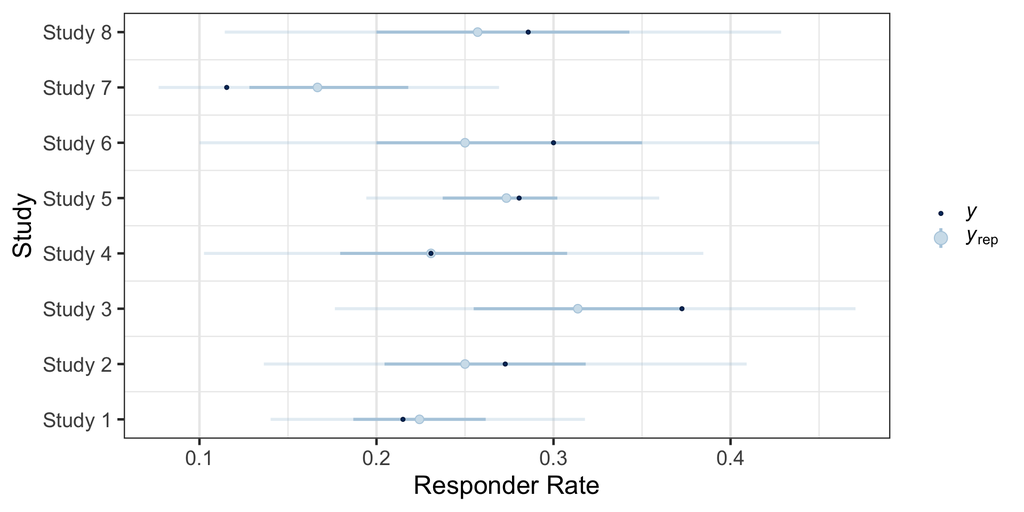

```r
with(AS_region, ppc_intervals(r / n, pp_rate_AS_region))  +
    scale_x_continuous("Study", breaks=1:nrow(AS_region), labels=AS_region$study) +
    ylab("Responder Rate") +
    coord_flip() +
    theme(legend.position="right",
          # suppress vertical grid lines for better readability of intervals
          panel.grid.major.y = element_blank())
```

```r
pp_AS_region <- AS_region |>
    add_predicted_rvars(map_mc_brms, value="pp_r") |>
    mutate(pp_rate=pp_r/n)

pp_AS_region
```

```
# A tibble: 8 × 6
  study       n     r region               pp_r       pp_rate
  <chr>   <dbl> <dbl> <chr>          <rvar[1d]>    <rvar[1d]>
1 Study 1   107    23 europe         24.2 ± 5.7  0.23 ± 0.053
2 Study 2    44    12 asia           11.5 ± 3.5  0.26 ± 0.080
3 Study 3    51    19 europe         16.1 ± 4.4  0.32 ± 0.086
4 Study 4    39     9 europe          9.5 ± 3.3  0.24 ± 0.085
5 Study 5   139    39 asia           37.8 ± 6.9  0.27 ± 0.050
6 Study 6    20     6 north_america   5.3 ± 2.3  0.27 ± 0.115
7 Study 7    78     9 europe         13.5 ± 4.7  0.17 ± 0.060
8 Study 8    35    10 asia            9.3 ± 3.2  0.27 ± 0.091
```

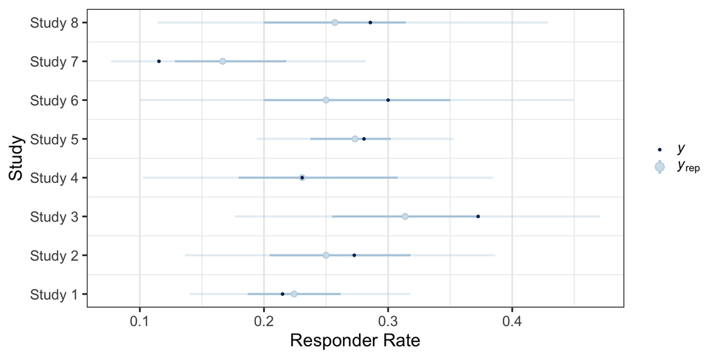

```r
with(pp_AS_region, ppc_intervals(r / n, as_draws_matrix(pp_rate)))  +
    scale_x_continuous("Study", breaks=1:nrow(AS_region), labels=AS_region$study) +
    ylab("Responder Rate") +
    coord_flip() +
    theme(legend.position="right",
          # suppress vertical grid lines for better readability of intervals
          panel.grid.major.y = element_blank())
```

## Exercise 2: Fixed vs random effect

```r
AS_region_all <- data.frame(region=c("asia", "europe", "north_america", "other")) |>
    mutate(study=paste("new_study", region, sep="_"), r=0, n=6)

## to get brms to include the other factor level in the model, we have
## to add a fake row with region "other" and n=0
AS_region_2 <- mutate(bind_rows(AS_region, mutate(AS_region_all, n=0)[4,]),
                      region=factor(region, levels=c("asia", "europe", "north_america", "other")))

str(AS_region_2)
```

```
'data.frame':   9 obs. of  4 variables:
 $ study : chr  "Study 1" "Study 2" "Study 3" "Study 4" ...
 $ n     : num  107 44 51 39 139 20 78 35 0
 $ r     : num  23 12 19 9 39 6 9 10 0
 $ region: Factor w/ 4 levels "asia","europe",..: 2 1 2 2 1 3 2 1 4
```

```r
model_fixed <- bf(r | trials(n) ~ 1 + region + (1|study), family=binomial)

get_prior(model_fixed, AS_region_2)
```

```
                prior     class                coef group resp dpar nlpar lb ub tag       source
               (flat)         b                                                          default
               (flat)         b        regioneurope                                 (vectorized)
               (flat)         b regionnorth_america                                 (vectorized)
               (flat)         b         regionother                                 (vectorized)
 student_t(3, 0, 2.5) Intercept                                                          default
 student_t(3, 0, 2.5)        sd                                            0             default
 student_t(3, 0, 2.5)        sd                     study                  0        (vectorized)
 student_t(3, 0, 2.5)        sd           Intercept study                  0        (vectorized)
```

```r
model_fixed_prior <- prior(normal(0, 2), class=Intercept) +
    prior(normal(0, 1), class=sd, coef=Intercept, group=study) +
    prior(normal(0, log(2)/1.96), class=b)

fixed_mc_brms  <- brm(model_fixed, AS_region_2, prior=model_fixed_prior,
                      seed=4767,
                      silent = 2, refresh = 0, control=list(adapt_delta=0.99))

fixed_mc_brms
```

```
 Family: binomial
  Links: mu = logit
Formula: r | trials(n) ~ 1 + region + (1 | study)
   Data: AS_region_2 (Number of observations: 9)
  Draws: 4 chains, each with iter = 2000; warmup = 1000; thin = 1;
         total post-warmup draws = 4000

Multilevel Hyperparameters:
~study (Number of levels: 9)
              Estimate Est.Error l-95% CI u-95% CI Rhat Bulk_ESS Tail_ESS
sd(Intercept)     0.38      0.22     0.04     0.92 1.00     1314     1612

Regression Coefficients:
                    Estimate Est.Error l-95% CI u-95% CI Rhat Bulk_ESS Tail_ESS
Intercept              -1.02      0.23    -1.51    -0.57 1.00     1778     1669
regioneurope           -0.17      0.26    -0.66     0.34 1.00     2226     2381
regionnorth_america     0.03      0.31    -0.60     0.63 1.00     3351     2898
regionother             0.00      0.35    -0.68     0.66 1.00     3691     2599

Draws were sampled using sample(hmc). For each parameter, Bulk_ESS
and Tail_ESS are effective sample size measures, and Rhat is the potential
scale reduction factor on split chains (at convergence, Rhat = 1).
```

```r
post_regions <- posterior_linpred(fixed_mc_brms,
                                  newdata=AS_region_all,
                                  transform=TRUE,
                                  allow_new_levels=TRUE,
                                  sample_new_levels="gaussian")

head(post_regions) |> kable(digits=3)
```

| 0.276 | 0.198 | 0.193 | 0.332 |
| --- | --- | --- | --- |
| 0.274 | 0.175 | 0.295 | 0.318 |
| 0.246 | 0.202 | 0.348 | 0.228 |
| 0.267 | 0.221 | 0.214 | 0.231 |
| 0.319 | 0.234 | 0.237 | 0.196 |
| 0.200 | 0.247 | 0.226 | 0.161 |

```r
colnames(post_regions) <- AS_region_all$region
map_region <- list()
for(r in AS_region_all$region) {
    map_region[[r]] <- mixfit(post_regions[,r], type="beta", Nc=3, constrain_gt1=TRUE)
}

kable(bind_rows(lapply(map_region, summary), .id="MAP"), digits=3)
```

| MAP | mean | sd | 2.5% | 50.0% | 97.5% |
| --- | --- | --- | --- | --- | --- |
| asia | 0.275 | 0.094 | 0.111 | 0.267 | 0.516 |
| europe | 0.242 | 0.087 | 0.098 | 0.231 | 0.464 |
| north_america | 0.283 | 0.109 | 0.101 | 0.271 | 0.545 |
| other | 0.279 | 0.112 | 0.096 | 0.267 | 0.540 |

```r
sapply(map_region, ess)
```

```
         asia        europe north_america         other
         32.6          33.6          18.4          16.3
```

## Exercise 3: Normal endpoint meta-analysis

```r
crohn <- RBesT::crohn

crohn_sigma <- 88
crohn$y.se <- crohn_sigma/sqrt(crohn$n)

library(RBesT)
set.seed(1234)
rbest_normal_map_mcmc <- gMAP(cbind(y, y.se) ~ 1 | study,
                              weights=n, data=crohn,
                              family=gaussian,
                              beta.prior=cbind(0, crohn_sigma),
                              tau.dist="HalfNormal",tau.prior=cbind(0,crohn_sigma/2))

model_normal <- bf(y | se(y.se) ~ 1 + (1 | study), family=gaussian())

prior_normal <- prior(normal(0, 88), class=Intercept) +
    prior(normal(0, 88/2), class=sd, coef=Intercept, group=study)

brms_normal_map_mcmc <- brm(model_normal, crohn, prior=prior_normal,
                            seed=4767,
                            silent = 2, refresh = 0, control=list(adapt_delta=0.99))

## comparing the outputs we see that the random effect posterior
## matches...
rbest_normal_map_mcmc
```

```
Generalized Meta Analytic Predictive Prior Analysis

Call:  gMAP(formula = cbind(y, y.se) ~ 1 | study, family = gaussian,
    data = crohn, weights = n, tau.dist = "HalfNormal", tau.prior = cbind(0,
        crohn_sigma/2), beta.prior = cbind(0, crohn_sigma))

Exchangeability tau strata: 1
Prediction tau stratum    : 1
Maximal Rhat              : 1
Estimated reference scale : 88

Between-trial heterogeneity of tau prediction stratum
       mean median   sd q2.5  q50 q97.5
tau[1] 14.4   12.7 9.48 1.37 12.7  38.1

MAP Prior MCMC sample
                 mean median   sd  q2.5   q50 q97.5
theta_resp_pred -50.1  -48.6 19.3 -92.8 -48.6 -10.9
```

```r
brms_normal_map_mcmc
```

```
 Family: gaussian
  Links: mu = identity
Formula: y | se(y.se) ~ 1 + (1 | study)
   Data: crohn (Number of observations: 6)
  Draws: 4 chains, each with iter = 2000; warmup = 1000; thin = 1;
         total post-warmup draws = 4000

Multilevel Hyperparameters:
~study (Number of levels: 6)
              Estimate Est.Error l-95% CI u-95% CI Rhat Bulk_ESS Tail_ESS
sd(Intercept)    14.25     10.02     1.07    40.33 1.00      699      885

Regression Coefficients:
          Estimate Est.Error l-95% CI u-95% CI Rhat Bulk_ESS Tail_ESS
Intercept   -49.26      9.10   -68.11   -32.85 1.00     1061     1037

Further Distributional Parameters:
      Estimate Est.Error l-95% CI u-95% CI Rhat Bulk_ESS Tail_ESS
sigma     0.00      0.00     0.00     0.00   NA       NA       NA

Draws were sampled using sample(hmc). For each parameter, Bulk_ESS
and Tail_ESS are effective sample size measures, and Rhat is the potential
scale reduction factor on split chains (at convergence, Rhat = 1).
```

```r
brms_normal_map <- posterior_epred(brms_normal_map_mcmc,
                                   newdata=data.frame(study="new", n=1, y=0, y.se=88),
                                   allow_new_levels=TRUE,
                                   sample_new_levels="gaussian")

## ... and the MAP prior is also the same
summarise_draws(brms_normal_map, mean, sd, ~quantile2(., probs = c(0.025, 0.5, 0.975)))
```

```
# A tibble: 1 × 6
  variable  mean    sd  q2.5   q50 q97.5
  <chr>    <dbl> <dbl> <dbl> <dbl> <dbl>
1 ...1     -48.9  18.8 -90.4 -48.0 -10.5
```

# Dose-finding

## Peanut allergy exercise overview

These exercises accompany the [dose finding](https://opensource.nibr.com/bamdd/src/02b_dose_finding.html) case study.

In a hypothetical phase 2b trial children and adolescents with peanut allergy were randomly assigned to placebo or 5 doses (5 to 300 mg) of a new drug.

After 26 weeks the patients underwent a double-blind placebo-controlled food challenge and the primary endpoint was the proportion of patients that could ingest 600 mg or more of peanut protein without experiencing dose-limiting symptoms.

The plots below show an overview of the data. Note that no placebo patients were considered “responders” per the primary endpoint definition.

**Show data setup code**

```r
peanut <- tibble(
  TRT01P = structure(c(
    6L, 6L, 6L, 6L, 6L, 6L, 6L, 6L, 6L, 6L, 6L, 6L, 6L, 6L, 6L, 6L, 6L, 6L, 6L, 6L, 6L, 6L, 6L, 6L, 6L, 6L, 6L, 6L,
    6L, 6L, 6L, 6L, 6L, 6L, 6L, 6L, 6L, 6L, 6L, 6L, 6L, 6L, 6L, 6L, 6L, 6L, 6L, 6L, 6L, 6L, 5L, 5L, 5L, 5L, 5L, 5L,
    5L, 5L, 5L, 5L, 5L, 5L, 5L, 5L, 5L, 5L, 5L, 5L, 5L, 5L, 5L, 5L, 5L, 5L, 5L, 5L, 5L, 5L, 5L, 5L, 5L, 5L, 5L, 5L,
    5L, 5L, 5L, 5L, 5L, 5L, 5L, 5L, 5L, 5L, 5L, 5L, 5L, 5L, 5L, 5L, 4L, 4L, 4L, 4L, 4L, 4L, 4L, 4L, 4L, 4L, 4L, 4L,
    4L, 4L, 4L, 4L, 4L, 4L, 4L, 4L, 4L, 4L, 4L, 4L, 4L, 4L, 4L, 4L, 4L, 4L, 4L, 4L, 4L, 4L, 4L, 4L, 4L, 4L, 4L, 4L,
    4L, 4L, 4L, 4L, 4L, 4L, 4L, 4L, 4L, 4L, 3L, 3L, 3L, 3L, 3L, 3L, 3L, 3L, 3L, 3L, 3L, 3L, 3L, 3L, 3L, 3L, 3L, 3L,
    3L, 3L, 3L, 3L, 3L, 3L, 3L, 3L, 3L, 3L, 3L, 3L, 3L, 3L, 3L, 3L, 3L, 3L, 3L, 3L, 3L, 3L, 3L, 3L, 3L, 3L, 3L, 3L,
    3L, 3L, 3L, 3L, 2L, 2L, 2L, 2L, 2L, 2L, 2L, 2L, 2L, 2L, 2L, 2L, 2L, 2L, 2L, 2L, 2L, 2L, 2L, 2L, 2L, 2L, 2L, 2L,
    2L, 2L, 2L, 2L, 2L, 2L, 2L, 2L, 2L, 2L, 2L, 2L, 2L, 2L, 2L, 2L, 2L, 2L, 2L, 2L, 2L, 2L, 2L, 2L, 2L, 2L, 1L, 1L,
    1L, 1L, 1L, 1L, 1L, 1L, 1L, 1L, 1L, 1L, 1L, 1L, 1L, 1L, 1L, 1L, 1L, 1L, 1L, 1L, 1L, 1L, 1L, 1L, 1L, 1L, 1L, 1L,
    1L, 1L, 1L, 1L, 1L, 1L, 1L, 1L, 1L, 1L, 1L, 1L, 1L, 1L, 1L, 1L, 1L, 1L, 1L, 1L
  ),levels = c("PBO", "5 mg", "15 mg", "50 mg", "150 mg", "300 mg"), class = "factor"),
  dose = c(
    300L, 300L, 300L, 300L, 300L, 300L, 300L, 300L, 300L, 300L, 300L, 300L, 300L, 300L, 300L, 300L, 300L, 300L, 300L,
    300L, 300L, 300L, 300L, 300L, 300L, 300L, 300L, 300L, 300L, 300L, 300L, 300L, 300L, 300L, 300L, 300L, 300L, 300L,
    300L, 300L, 300L, 300L, 300L, 300L, 300L, 300L, 300L, 300L, 300L, 300L, 150L, 150L, 150L, 150L, 150L, 150L, 150L,
    150L, 150L, 150L, 150L, 150L, 150L, 150L, 150L, 150L, 150L, 150L, 150L, 150L, 150L, 150L, 150L, 150L, 150L, 150L,
    150L, 150L, 150L, 150L, 150L, 150L, 150L, 150L, 150L, 150L, 150L, 150L, 150L, 150L, 150L, 150L, 150L, 150L, 150L,
    150L, 150L, 150L, 150L, 150L, 50L, 50L, 50L, 50L, 50L, 50L, 50L, 50L, 50L, 50L, 50L, 50L, 50L, 50L, 50L, 50L, 50L,
    50L, 50L, 50L, 50L, 50L, 50L, 50L, 50L, 50L, 50L, 50L, 50L, 50L, 50L, 50L, 50L, 50L, 50L, 50L, 50L, 50L, 50L, 50L,
    50L, 50L, 50L, 50L, 50L, 50L, 50L, 50L, 50L, 50L, 15L, 15L, 15L, 15L, 15L, 15L, 15L, 15L, 15L, 15L, 15L, 15L, 15L,
    15L, 15L, 15L, 15L, 15L, 15L, 15L, 15L, 15L, 15L, 15L, 15L, 15L, 15L, 15L, 15L, 15L, 15L, 15L, 15L, 15L, 15L, 15L,
    15L, 15L, 15L, 15L, 15L, 15L, 15L, 15L, 15L, 15L, 15L, 15L, 15L, 15L, 5L, 5L, 5L, 5L, 5L, 5L, 5L, 5L, 5L, 5L, 5L,
    5L, 5L, 5L, 5L, 5L, 5L, 5L, 5L, 5L, 5L, 5L, 5L, 5L, 5L, 5L, 5L, 5L, 5L, 5L, 5L, 5L, 5L, 5L, 5L, 5L, 5L, 5L, 5L, 5L,
    5L, 5L, 5L, 5L, 5L, 5L, 5L, 5L, 5L, 5L, 0L, 0L, 0L, 0L, 0L, 0L, 0L, 0L, 0L, 0L, 0L, 0L, 0L, 0L, 0L, 0L, 0L, 0L, 0L,
    0L, 0L, 0L, 0L, 0L, 0L, 0L, 0L, 0L, 0L, 0L, 0L, 0L, 0L, 0L, 0L, 0L, 0L, 0L, 0L, 0L, 0L, 0L, 0L, 0L, 0L, 0L, 0L, 0L,
    0L, 0L),
  AVAL = c(
    1000L, 100L, 0L, 600L, 600L, 300L, 300L, 10L, 10L, 100L, 1000L, 300L, 10L, 1000L, 1000L, 1000L, 3L, 3L, 600L, 300L,
    1000L, 1000L, 100L, 1000L, 600L, 600L, 1000L, 1000L, 1000L, 300L, 600L, 1000L, 1000L, 1000L, 1000L, 1000L, 300L,
    1000L, 600L, 1000L, 300L, 1000L, 600L, 600L, 1000L, 1000L, 600L, 1000L, 1000L, 1000L, 1000L, 600L, 1000L, 1000L,
    1000L, 0L, 600L, 300L, 1000L, 1000L, 1000L, 100L, 1000L, 1000L, 600L, 1000L, 1000L, 1000L, 600L, 300L, 600L, 600L,
    100L, 600L, 1000L, 300L, 10L, 3L, 1000L, 300L, 300L, 1000L, 300L, 300L, 10L, 1000L, 1000L, 10L, 10L, 600L, 3L, 10L,
    600L, 600L, 600L, 1000L, 100L, 1000L, 1000L, 10L, 1000L, 3L, 10L, 1000L, 100L, 1000L, 100L, 10L, 300L, 10L, 100L,
    1000L, 0L, 1000L, 100L, 3L, 10L, 100L, 100L, 300L, 1000L, 1000L, 1000L, 10L, 1000L, 3L, 3L, 600L, 600L, 10L, 3L,
    600L, 600L, 300L, 300L, 1000L, 3L, 3L, 1000L, 10L, 1000L, 1000L, 600L, 100L, 300L, 600L, 10L, 100L, 0L, 100L, 3L,
    0L, 10L, 3L, 600L, 300L, 300L, 300L, 600L, 300L, 100L, 3L, 0L, 10L, 600L, 300L, 10L, 300L, 600L, 1000L, 600L, 600L,
    0L, 0L, 600L, 600L, 600L, 0L, 0L, 300L, 100L, 0L, 10L, 300L, 1000L, 300L, 600L, 600L, 300L, 10L, 600L, 100L, 100L,
    300L, 3L, 3L, 300L, 1000L, 10L, 3L, 100L, 3L, 100L, 100L, 300L, 3L, 3L, 600L, 300L, 3L, 3L, 3L, 300L, 3L, 0L, 10L,
    3L, 300L, 10L, 10L, 600L, 0L, 300L, 600L, 0L, 0L, 100L, 100L, 10L, 100L, 10L, 100L, 600L, 0L, 600L, 0L, 10L, 100L,
    0L, 0L, 0L, 0L, 3L, 10L, 3L, 300L, 600L, 0L, 0L, 300L, 10L, 10L, 100L, 300L, 0L, 0L, 0L, 3L, 0L, 0L, 10L, 0L, 300L,
    3L, 0L, 0L, 0L, 0L, 100L, 3L, 0L, 3L, 10L, 10L, 3L, 0L, 3L, 10L, 3L, 0L, 0L, 3L, 100L, 0L, 0L, 300L, 0L, 0L, 0L,
    0L, 0L, 0L, 0L, 3L, 0L, 3L, 0L, 0L, 0L, 0L),
  PARAM = structure(
    c(
      1L, 1L, 1L, 1L, 1L, 1L, 1L, 1L, 1L, 1L, 1L, 1L, 1L, 1L, 1L, 1L, 1L, 1L, 1L, 1L, 1L, 1L, 1L, 1L, 1L, 1L, 1L, 1L,
      1L, 1L, 1L, 1L, 1L, 1L, 1L, 1L, 1L, 1L, 1L, 1L, 1L, 1L, 1L, 1L, 1L, 1L, 1L, 1L, 1L, 1L, 1L, 1L, 1L, 1L, 1L, 1L,
      1L, 1L, 1L, 1L, 1L, 1L, 1L, 1L, 1L, 1L, 1L, 1L, 1L, 1L, 1L, 1L, 1L, 1L, 1L, 1L, 1L, 1L, 1L, 1L, 1L, 1L, 1L, 1L,
      1L, 1L, 1L, 1L, 1L, 1L, 1L, 1L, 1L, 1L, 1L, 1L, 1L, 1L, 1L, 1L, 1L, 1L, 1L, 1L, 1L, 1L, 1L, 1L, 1L, 1L, 1L, 1L,
      1L, 1L, 1L, 1L, 1L, 1L, 1L, 1L, 1L, 1L, 1L, 1L, 1L, 1L, 1L, 1L, 1L, 1L, 1L, 1L, 1L, 1L, 1L, 1L, 1L, 1L, 1L, 1L,
      1L, 1L, 1L, 1L, 1L, 1L, 1L, 1L, 1L, 1L, 1L, 1L, 1L, 1L, 1L, 1L, 1L, 1L, 1L, 1L, 1L, 1L, 1L, 1L, 1L, 1L, 1L, 1L,
      1L, 1L, 1L, 1L, 1L, 1L, 1L, 1L, 1L, 1L, 1L, 1L, 1L, 1L, 1L, 1L, 1L, 1L, 1L, 1L, 1L, 1L, 1L, 1L, 1L, 1L, 1L, 1L,
      1L, 1L, 1L, 1L, 1L, 1L, 1L, 1L, 1L, 1L, 1L, 1L, 1L, 1L, 1L, 1L, 1L, 1L, 1L, 1L, 1L, 1L, 1L, 1L, 1L, 1L, 1L, 1L,
      1L, 1L, 1L, 1L, 1L, 1L, 1L, 1L, 1L, 1L, 1L, 1L, 1L, 1L, 1L, 1L, 1L, 1L, 1L, 1L, 1L, 1L, 1L, 1L, 1L, 1L, 1L, 1L,
      1L, 1L, 1L, 1L, 1L, 1L, 1L, 1L, 1L, 1L, 1L, 1L, 1L, 1L, 1L, 1L, 1L, 1L, 1L, 1L, 1L, 1L, 1L, 1L, 1L, 1L, 1L, 1L,
      1L, 1L, 1L, 1L, 1L, 1L, 1L, 1L, 1L, 1L, 1L, 1L, 1L, 1L, 1L, 1L, 1L, 1L, 1L, 1L),
    levels = "Tolerated amount of peanut protein (mg)", class = "factor"),
  USUBJID = c(
    129L, 103L, 104L, 185L, 34L, 15L, 140L, 151L, 7L, 144L, 200L, 23L, 138L, 115L, 255L, 147L, 224L, 101L, 156L, 284L,
    136L, 248L, 179L, 298L, 168L, 295L, 289L, 241L, 36L, 27L, 123L, 266L, 11L, 291L, 236L, 130L, 173L, 195L, 203L, 160L,
    274L, 167L, 290L, 94L, 9L, 269L, 122L, 135L, 64L, 26L, 95L, 10L, 5L, 234L, 161L, 299L, 88L, 69L, 35L, 233L, 286L,
    85L, 91L, 189L, 80L, 152L, 223L, 287L, 244L, 57L, 108L, 18L, 62L, 157L, 300L, 283L, 164L, 243L, 89L, 220L, 24L, 271L,
    166L, 118L, 201L, 127L, 121L, 41L, 267L, 213L, 49L, 73L, 202L, 134L, 112L, 25L, 227L, 29L, 251L, 273L, 119L, 132L,
    74L, 270L, 83L, 37L, 181L, 258L, 253L, 48L, 120L, 54L, 277L, 176L, 65L, 264L, 107L, 171L, 262L, 162L, 187L, 272L,
    288L, 294L, 245L, 109L, 172L, 204L, 275L, 22L, 66L, 186L, 247L, 17L, 149L, 141L, 177L, 280L, 216L, 40L, 75L, 263L,
    246L, 14L, 81L, 260L, 153L, 45L, 237L, 8L, 117L, 86L, 296L, 146L, 154L, 116L, 38L, 100L, 191L, 175L, 92L, 158L, 192L,
    180L, 256L, 254L, 125L, 222L, 145L, 261L, 155L, 159L, 3L, 206L, 278L, 19L, 31L, 63L, 208L, 55L, 259L, 218L, 111L,
    226L, 33L, 2L, 44L, 297L, 53L, 87L, 16L, 28L, 90L, 207L, 56L, 137L, 128L, 178L, 142L, 143L, 148L, 193L, 229L, 265L,
    97L, 252L, 205L, 150L, 165L, 188L, 52L, 99L, 93L, 1L, 221L, 124L, 210L, 6L, 232L, 21L, 211L, 163L, 96L, 60L, 183L,
    190L, 242L, 42L, 46L, 67L, 126L, 209L, 72L, 194L, 238L, 184L, 39L, 105L, 249L, 61L, 113L, 30L, 77L, 12L, 4L, 51L,
    139L, 20L, 268L, 215L, 292L, 217L, 199L, 32L, 276L, 47L, 225L, 230L, 79L, 71L, 98L, 50L, 13L, 76L, 231L, 250L, 58L,
    68L, 239L, 198L, 293L, 212L, 110L, 59L, 182L, 133L, 170L, 43L, 282L, 281L, 131L, 114L, 196L, 214L, 285L, 70L, 102L,
    279L, 106L, 197L, 257L, 228L, 84L, 235L, 78L, 169L, 240L, 219L, 174L, 82L),
  CRIT1 = structure(c(
    1L, 1L, 1L, 1L, 1L, 1L, 1L, 1L, 1L, 1L, 1L, 1L, 1L, 1L, 1L, 1L, 1L, 1L, 1L, 1L, 1L, 1L, 1L, 1L, 1L, 1L, 1L, 1L,
    1L, 1L, 1L, 1L, 1L, 1L, 1L, 1L, 1L, 1L, 1L, 1L, 1L, 1L, 1L, 1L, 1L, 1L, 1L, 1L, 1L, 1L, 1L, 1L, 1L, 1L, 1L, 1L,
    1L, 1L, 1L, 1L, 1L, 1L, 1L, 1L, 1L, 1L, 1L, 1L, 1L, 1L, 1L, 1L, 1L, 1L, 1L, 1L, 1L, 1L, 1L, 1L, 1L, 1L, 1L, 1L,
    1L, 1L, 1L, 1L, 1L, 1L, 1L, 1L, 1L, 1L, 1L, 1L, 1L, 1L, 1L, 1L, 1L, 1L, 1L, 1L, 1L, 1L, 1L, 1L, 1L, 1L, 1L, 1L,
    1L, 1L, 1L, 1L, 1L, 1L, 1L, 1L, 1L, 1L, 1L, 1L, 1L, 1L, 1L, 1L, 1L, 1L, 1L, 1L, 1L, 1L, 1L, 1L, 1L, 1L, 1L, 1L,
    1L, 1L, 1L, 1L, 1L, 1L, 1L, 1L, 1L, 1L, 1L, 1L, 1L, 1L, 1L, 1L, 1L, 1L, 1L, 1L, 1L, 1L, 1L, 1L, 1L, 1L, 1L, 1L,
    1L, 1L, 1L, 1L, 1L, 1L, 1L, 1L, 1L, 1L, 1L, 1L, 1L, 1L, 1L, 1L, 1L, 1L, 1L, 1L, 1L, 1L, 1L, 1L, 1L, 1L, 1L, 1L,
    1L, 1L, 1L, 1L, 1L, 1L, 1L, 1L, 1L, 1L, 1L, 1L, 1L, 1L, 1L, 1L, 1L, 1L, 1L, 1L, 1L, 1L, 1L, 1L, 1L, 1L, 1L, 1L,
    1L, 1L, 1L, 1L, 1L, 1L, 1L, 1L, 1L, 1L, 1L, 1L, 1L, 1L, 1L, 1L, 1L, 1L, 1L, 1L, 1L, 1L, 1L, 1L, 1L, 1L, 1L, 1L,
    1L, 1L, 1L, 1L, 1L, 1L, 1L, 1L, 1L, 1L, 1L, 1L, 1L, 1L, 1L, 1L, 1L, 1L, 1L, 1L, 1L, 1L, 1L, 1L, 1L, 1L, 1L, 1L,
    1L, 1L, 1L, 1L, 1L, 1L, 1L, 1L, 1L, 1L, 1L, 1L, 1L, 1L, 1L, 1L, 1L, 1L, 1L, 1L),
    levels = "Tolerating >=600 mg of peanut protein without dose-limiting symptoms", class = "factor"),
  CRIT1FL = structure(c(
    2L, 1L, 1L, 2L, 2L, 1L, 1L, 1L, 1L, 1L, 2L, 1L, 1L, 2L, 2L, 2L, 1L, 1L, 2L, 1L, 2L, 2L, 1L, 2L, 2L, 2L, 2L, 2L,
    2L, 1L, 2L, 2L, 2L, 2L, 2L, 2L, 1L, 2L, 2L, 2L, 1L, 2L, 2L, 2L, 2L, 2L, 2L, 2L, 2L, 2L, 2L, 2L, 2L, 2L, 2L, 1L,
    2L, 1L, 2L, 2L, 2L, 1L, 2L, 2L, 2L, 2L, 2L, 2L, 2L, 1L, 2L, 2L, 1L, 2L, 2L, 1L, 1L, 1L, 2L, 1L, 1L, 2L, 1L, 1L,
    1L, 2L, 2L, 1L, 1L, 2L, 1L, 1L, 2L, 2L, 2L, 2L, 1L, 2L, 2L, 1L, 2L, 1L, 1L, 2L, 1L, 2L, 1L, 1L, 1L, 1L, 1L, 2L,
    1L, 2L, 1L, 1L, 1L, 1L, 1L, 1L, 2L, 2L, 2L, 1L, 2L, 1L, 1L, 2L, 2L, 1L, 1L, 2L, 2L, 1L, 1L, 2L, 1L, 1L, 2L, 1L,
    2L, 2L, 2L, 1L, 1L, 2L, 1L, 1L, 1L, 1L, 1L, 1L, 1L, 1L, 2L, 1L, 1L, 1L, 2L, 1L, 1L, 1L, 1L, 1L, 2L, 1L, 1L, 1L,
    2L, 2L, 2L, 2L, 1L, 1L, 2L, 2L, 2L, 1L, 1L, 1L, 1L, 1L, 1L, 1L, 2L, 1L, 2L, 2L, 1L, 1L, 2L, 1L, 1L, 1L, 1L, 1L,
    1L, 2L, 1L, 1L, 1L, 1L, 1L, 1L, 1L, 1L, 1L, 2L, 1L, 1L, 1L, 1L, 1L, 1L, 1L, 1L, 1L, 1L, 1L, 1L, 2L, 1L, 1L, 2L,
    1L, 1L, 1L, 1L, 1L, 1L, 1L, 1L, 2L, 1L, 2L, 1L, 1L, 1L, 1L, 1L, 1L, 1L, 1L, 1L, 1L, 1L, 2L, 1L, 1L, 1L, 1L, 1L,
    1L, 1L, 1L, 1L, 1L, 1L, 1L, 1L, 1L, 1L, 1L, 1L, 1L, 1L, 1L, 1L, 1L, 1L, 1L, 1L, 1L, 1L, 1L, 1L, 1L, 1L, 1L, 1L,
    1L, 1L, 1L, 1L, 1L, 1L, 1L, 1L, 1L, 1L, 1L, 1L, 1L, 1L, 1L, 1L, 1L, 1L, 1L, 1L),
    levels = c("N", "Y"), class = "factor"),
  CRIT2 = structure(c(
    1L, 1L, 1L, 1L, 1L, 1L, 1L, 1L, 1L, 1L, 1L, 1L, 1L, 1L, 1L, 1L, 1L, 1L, 1L, 1L, 1L, 1L, 1L, 1L, 1L, 1L, 1L, 1L,
    1L, 1L, 1L, 1L, 1L, 1L, 1L, 1L, 1L, 1L, 1L, 1L, 1L, 1L, 1L, 1L, 1L, 1L, 1L, 1L, 1L, 1L, 1L, 1L, 1L, 1L, 1L, 1L,
    1L, 1L, 1L, 1L, 1L, 1L, 1L, 1L, 1L, 1L, 1L, 1L, 1L, 1L, 1L, 1L, 1L, 1L, 1L, 1L, 1L, 1L, 1L, 1L, 1L, 1L, 1L, 1L,
    1L, 1L, 1L, 1L, 1L, 1L, 1L, 1L, 1L, 1L, 1L, 1L, 1L, 1L, 1L, 1L, 1L, 1L, 1L, 1L, 1L, 1L, 1L, 1L, 1L, 1L, 1L, 1L,
    1L, 1L, 1L, 1L, 1L, 1L, 1L, 1L, 1L, 1L, 1L, 1L, 1L, 1L, 1L, 1L, 1L, 1L, 1L, 1L, 1L, 1L, 1L, 1L, 1L, 1L, 1L, 1L,
    1L, 1L, 1L, 1L, 1L, 1L, 1L, 1L, 1L, 1L, 1L, 1L, 1L, 1L, 1L, 1L, 1L, 1L, 1L, 1L, 1L, 1L, 1L, 1L, 1L, 1L, 1L, 1L,
    1L, 1L, 1L, 1L, 1L, 1L, 1L, 1L, 1L, 1L, 1L, 1L, 1L, 1L, 1L, 1L, 1L, 1L, 1L, 1L, 1L, 1L, 1L, 1L, 1L, 1L, 1L, 1L,
    1L, 1L, 1L, 1L, 1L, 1L, 1L, 1L, 1L, 1L, 1L, 1L, 1L, 1L, 1L, 1L, 1L, 1L, 1L, 1L, 1L, 1L, 1L, 1L, 1L, 1L, 1L, 1L,
    1L, 1L, 1L, 1L, 1L, 1L, 1L, 1L, 1L, 1L, 1L, 1L, 1L, 1L, 1L, 1L, 1L, 1L, 1L, 1L, 1L, 1L, 1L, 1L, 1L, 1L, 1L, 1L,
    1L, 1L, 1L, 1L, 1L, 1L, 1L, 1L, 1L, 1L, 1L, 1L, 1L, 1L, 1L, 1L, 1L, 1L, 1L, 1L, 1L, 1L, 1L, 1L, 1L, 1L, 1L, 1L,
    1L, 1L, 1L, 1L, 1L, 1L, 1L, 1L, 1L, 1L, 1L, 1L, 1L, 1L, 1L, 1L, 1L, 1L, 1L, 1L),
    levels = "Tolerating >=1000 mg of peanut protein without dose-limiting symptoms", class = "factor"),
  CRIT2FL = structure(c(
    2L, 1L, 1L, 1L, 1L, 1L, 1L, 1L, 1L, 1L, 2L, 1L, 1L, 2L, 2L, 2L, 1L, 1L, 1L, 1L, 2L, 2L, 1L, 2L, 1L, 1L, 2L, 2L,
```

```r
    2L, 1L, 1L, 2L, 2L, 2L, 2L, 2L, 1L, 2L, 1L, 2L, 1L, 2L, 1L, 1L, 2L, 2L, 1L, 2L, 2L, 2L, 2L, 1L, 2L, 2L, 2L, 1L,
    1L, 1L, 2L, 2L, 2L, 1L, 2L, 2L, 1L, 2L, 2L, 2L, 1L, 1L, 1L, 1L, 1L, 1L, 2L, 1L, 1L, 1L, 2L, 1L, 1L, 2L, 1L, 1L,
    1L, 2L, 2L, 1L, 1L, 1L, 1L, 1L, 1L, 1L, 1L, 2L, 1L, 2L, 2L, 1L, 2L, 1L, 1L, 2L, 1L, 2L, 1L, 1L, 1L, 1L, 1L, 2L,
    1L, 2L, 1L, 1L, 1L, 1L, 1L, 1L, 2L, 2L, 2L, 1L, 2L, 1L, 1L, 1L, 1L, 1L, 1L, 1L, 1L, 1L, 1L, 2L, 1L, 1L, 2L, 1L,
    2L, 2L, 1L, 1L, 1L, 1L, 1L, 1L, 1L, 1L, 1L, 1L, 1L, 1L, 1L, 1L, 1L, 1L, 1L, 1L, 1L, 1L, 1L, 1L, 1L, 1L, 1L, 1L,
    1L, 2L, 1L, 1L, 1L, 1L, 1L, 1L, 1L, 1L, 1L, 1L, 1L, 1L, 1L, 1L, 2L, 1L, 1L, 1L, 1L, 1L, 1L, 1L, 1L, 1L, 1L, 1L,
    1L, 2L, 1L, 1L, 1L, 1L, 1L, 1L, 1L, 1L, 1L, 1L, 1L, 1L, 1L, 1L, 1L, 1L, 1L, 1L, 1L, 1L, 1L, 1L, 1L, 1L, 1L, 1L,
    1L, 1L, 1L, 1L, 1L, 1L, 1L, 1L, 1L, 1L, 1L, 1L, 1L, 1L, 1L, 1L, 1L, 1L, 1L, 1L, 1L, 1L, 1L, 1L, 1L, 1L, 1L, 1L,
    1L, 1L, 1L, 1L, 1L, 1L, 1L, 1L, 1L, 1L, 1L, 1L, 1L, 1L, 1L, 1L, 1L, 1L, 1L, 1L, 1L, 1L, 1L, 1L, 1L, 1L, 1L, 1L,
    1L, 1L, 1L, 1L, 1L, 1L, 1L, 1L, 1L, 1L, 1L, 1L, 1L, 1L, 1L, 1L, 1L, 1L, 1L, 1L),
    levels = c("N", "Y"), class = "factor" ) )
```

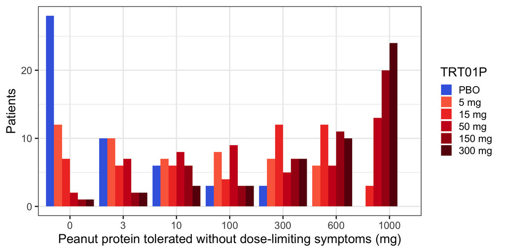

```r
peanut |>
  ggplot(aes(x=factor(AVAL), fill=TRT01P)) +
  geom_bar( position=position_dodge(preserve = "single")) +
  scale_fill_manual(values=c("royalblue", "#fb6a4a", "#ef3b2c", "#cb181d", "#a50f15", "#67000d")) +
  xlab("Peanut protein tolerated without dose-limiting symptoms (mg)") +
  ylab("Patients") +
  theme(legend.position="right")
```

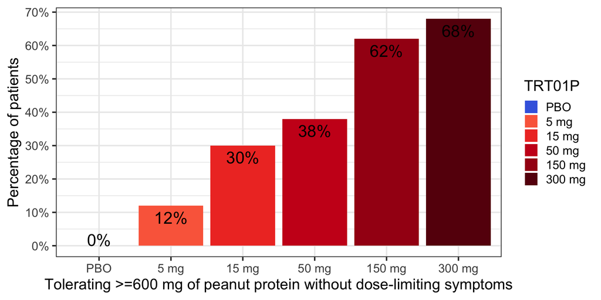

```r
peanut |>
  group_by(TRT01P) |>
  summarize(proportion = sum(CRIT1FL=="Y") / n()) |>
  ggplot(aes(x=TRT01P, y=proportion, fill=TRT01P)) +
  geom_bar(stat="identity", position=position_dodge()) +
  geom_text(aes(label=scales::percent(proportion)), size=7, vjust=c(0, rep(1.5, 5))) +
  scale_fill_manual(values=c("royalblue", "#fb6a4a", "#ef3b2c", "#cb181d", "#a50f15", "#67000d")) +
  scale_y_continuous(breaks=seq(0, 0.7, 0.1), labels=scales::percent) +
  xlab("Tolerating >=600 mg of peanut protein without dose-limiting symptoms") +
  ylab("Percentage of patients")
```

## Exercise 1: Emax logistic regression

Fit a sigmoid Emax logistic regression model (i.e. `family=binomial(link="logit")`). To accelerate likelihood evaluations, first summarize data as “responders” `y` out of `n` patients per dose. We tell `brms` to use this information using `y | trials(n) ~ ...`.

We expect the true placebo proportion to be around 0.05 (-2.944 on the logit scale) with much more than 0.1 or much less than 0.02 considered unlikely. It is a-priori at least possible that there is a huge treatment effect such as 95% versus 5% responders (difference on the logit scale close to 6), but we are at least mildly skeptical.

The dose response is a-priori somewhat likely to follow an Emax curve (with Hill parameter near 1), but we wish to allow for the possibility of a steeper or shallower curve. The dose with half the effect (ED50) might be near 15 mg, but have considerable uncertainty around that.

```r
model1 <- bf( #---- YOUR CODE HERE --- # ~ E0 + Emax * dose^h/(dose^h + ED50^h),
              family= #---- YOUR CODE HERE --- # ,
              nlf(h ~ exp(logh)), nlf(ED50 ~ exp(logED50)),
              E0 ~ 1, logED50 ~ 1, logh ~ 1, Emax ~ 1,
              nl=TRUE)

priors1 <- prior(normal(-2.944, 0.38), nlpar=E0) +
           prior(normal(0, log(4)/1.96), nlpar=logh) +
           prior(normal(0, 6), nlpar=Emax) +
           prior(normal(2.7, 2.5), nlpar=logED50)
```

Now fit the model

```r
brmfit1 <- brm(
  formula = model1,
  prior = priors1,
  data = summarize(peanut, y=sum(CRIT1FL=="Y"), n=n(), .by=c(TRT01P, dose))
)
```

## Exercise 1: reading the `brms` code

- `y | trials(n) ~ ...`: a binomial outcome needs the number of trials. Summarizing patients as `y` responders out of `n` per dose gives the same posterior as one row per patient, but fits faster.
- `nl=TRUE`: the right-hand side is a non-linear formula. Every unknown name (`E0`, `Emax`, `logh`, `logED50`) is a *non-linear parameter* with its own formula, here `~ 1`: one value shared by all patients.
- `nlf(h ~ exp(logh))`: defines `h` from other parameters. Estimating `logh` and `logED50` on the whole real line and exponentiating keeps `h` and `ED50` positive.
- `prior(..., nlpar=E0)`: priors refer to non-linear parameters via `nlpar`. On the logit scale, `E0` is the placebo log-odds and `Emax` the maximal log-odds ratio vs. placebo.

The priors translate the beliefs described above:

- `E0 ~ N(-2.944, 0.38)`: 95% prior interval $[-3.69, -2.20]$, i.e. 2.4% to 10% placebo responders.
- `Emax ~ N(0, 6)`: a log-odds ratio of 6 (5% vs. 95%) is one SD away: possible, but we are mildly skeptical.
- `logh ~ N(0, log(4)/1.96)`: Hill parameter centered on $e^0 = 1$ (standard Emax), 95% between $1/4$ and $4$.
- `logED50 ~ N(2.7, 2.5)`: ED50 centered on $e^{2.7} \approx 15$ mg, with considerable uncertainty.

## Exercise 1: predictions

Now use

```r
tibble(dose = seq(0, 300, 1), n=1) |> tidybayes::add_epred_rvars(brmfit1)
```

to obtain predicted proportions for every dose from 0 to 300 mg.

Then, plot the curve of predicted proportions for each of these doses using `ggplot2` and `ggdist` (using `ydist=.epred` in the aesthetics and the `stat_lineribbon()` geom from the `ggdist` package).

If you prefer, replace the default fill colors e.g. with shades of blue using `+ scale_fill_brewer(palette="Blues")`

Next obtain the posterior distribution for the difference in proportions for each of these dose levels compared with placebo.

Hint: `add_epred_rvars()` returns `rvar` columns, each holding all posterior draws; arithmetic on them (e.g. `.epred - .epred_placebo`) is carried out draw by draw.

## Exercise 2: using more of the data

The primary endpoint throws information away: a patient who tolerated 300 mg and a patient who tolerated nothing are both just “non-responders”. The food challenge actually records, for every patient, the highest amount of peanut protein tolerated (`AVAL`): one of 0, 3, 10, 100, 300, 600 or 1000 mg.

We model this ordered outcome directly, in two different ways:

- **2a: interval censoring.** Each patient has an unobserved, continuous tolerance threshold; we only know between which two challenge steps it lies.
- **2b: ordinal regression.** The 7 outcomes are ordered categories; we make no assumption about the distances between them.

Both keep the sigmoid Emax curve from Exercise 1. Only the left-hand side of the formula (the response) and the `family` (the likelihood) change, which is typical for `brms`: the model for the mean and the outcome distribution are specified separately.

Both models still let us derive the primary endpoint, the proportion of patients tolerating $\geq$ 600 mg, so at the end we can compare all three analyses on the same scale.

## Exercise 2a: interval censoring, the idea

Let $T_i$ be the (unobserved) amount of peanut protein patient $i$ could tolerate. The challenge only tells us which interval $T_i$ lies in:

| `AVAL` (mg) | 0 | 3 | 10 | 100 | 300 | 600 | 1000 |
| --- | --- | --- | --- | --- | --- | --- | --- |
| $T_i$ (mg) in | [0, 3) | [3, 10) | [10, 100) | [100, 300) | [300, 600) | [600, 1000) | [1000, $\infty$) |

We assume $\log T_i \sim \mathrm{N}(\mu(d_i), \sigma^2)$ with the Emax model for the mean, $\mu(d) = E_0 + E_{\max}\, d^h / (d^h + \mathrm{ED}_{50}^h)$. A patient with $\log T_i \in [L_i, U_i)$ contributes the probability of that interval to the likelihood:

$$\Pr(L_i \le \log T_i < U_i) = \Phi\left(\frac{U_i - \mu(d_i)}{\sigma}\right) - \Phi\left(\frac{L_i - \mu(d_i)}{\sigma}\right)$$

In `brms`, the `cens()` *addition term* on the response requests exactly this: `lower | cens("interval", upper) ~ ...`, with `family = gaussian()`. On the log scale, the first and last intervals are open-ended ($-\infty$ to $\log 3$ and $\log 1000$ to $\infty$). The first argument of `cens()` may also be a *variable*, so each row can be censored differently: `"left"` (the response is an upper bound), `"right"` (the response is a lower bound), `"interval"` (response and second argument are the lower and upper ends) or `"none"`.

The parameters now live on the log-mg scale instead of the logit scale:

- $E_0$: mean of $\log T$ on placebo, so $e^{E_0}$ is the median tolerated amount (mg).
- $E_{\max}$: maximal shift on the log scale; the drug multiplies the median tolerated amount by up to $e^{E_{\max}}$.
- $\sigma$ (new): SD of $\log T$ between patients on the same dose.

## Exercise 2a: your task

The data with one censoring type per patient: left-censored below 3 mg, right-censored above 1000 mg, interval-censored otherwise.

```r
challenge_mg <- c(0, 3, 10, 100, 300, 600, 1000)

peanut_cens <- peanut |>
  mutate(censored = case_when(AVAL == 0 ~ "left",
                              AVAL == 1000 ~ "right",
                              TRUE ~ "interval"),
         # for left-censored rows the response is the upper bound log(3)
         logAVAL = ifelse(AVAL == 0, log(3), log(AVAL)),
         logAVALnext = ifelse(censored == "interval",
                              log(challenge_mg[match(AVAL, challenge_mg) + 1]), NA))
```

```r
model2 <- bf( #---- YOUR CODE HERE --- # ~ E0 + Emax * dose^h/(dose^h + ED50^h),
              family = #---- YOUR CODE HERE --- # ,
              nlf(h ~ exp(logh)), nlf(ED50 ~ exp(logED50)),
              E0 ~ 1, logED50 ~ 1, logh ~ 1, Emax ~ 1,
              nl=TRUE)

priors2 <- prior( #---- YOUR CODE HERE --- # , nlpar=E0) +
           prior(normal(0, log(4)/1.96), nlpar=logh) +
           prior( #---- YOUR CODE HERE --- # , nlpar=Emax) +
           prior(normal(2.7, 2.5), nlpar=logED50) +
           prior( #---- YOUR CODE HERE --- # , class=sigma)

brmfit2 <- brm(formula = model2, prior = priors2, data = peanut_cens)
```

Hints:

- The response goes left of `|`; `cens()` takes the censoring type and the upper interval end.
- `get_prior(model2, data = peanut_cens)` lists every parameter that needs a prior, including the new `sigma`.
- `logh` and `logED50` describe the *shape* of the dose response and need not change. `E0` and `Emax` are now on the log-mg scale: what is a plausible median tolerated amount on placebo, and how many-fold an increase is plausible?
- After fitting, look at `summary(brmfit2)` and transform `E0` and `Emax` back with `exp()`.

## Exercise 2b: ordinal regression, the idea

Treat `AVAL` as an ordered outcome $Y$ with $K = 7$ categories, $k = 1$ (0 mg) to $k = 7$ (1000 mg). The cumulative logit model (`family = cumulative(link = "logit", threshold = "flexible")`) is

$$\Pr(Y_i \le k \mid d_i) = \text{logit}^{-1}\big(\theta_k - \eta(d_i)\big), \quad k = 1, \ldots, K-1$$

- $\theta_1 < \cdots < \theta_6$ are ordered thresholds (cut-points). On placebo, $\eta(0) = 0$, so $\Pr(Y \le k) = \text{logit}^{-1}(\theta_k)$. These are *cumulative* probabilities; the probability of one category is a difference, $\Pr(Y = k) = \Pr(Y \le k) - \Pr(Y \le k - 1)$. The thresholds appear as `Intercept[1]`, …, `Intercept[6]` in `brms`; `"flexible"` means they are only constrained to be ordered.
- $\eta(d) = E_{\max}\, d^h / (d^h + \mathrm{ED}_{50}^h)$ is the Emax curve **without** $E_0$: adding a constant to $\eta$ and to all $\theta_k$ gives the same probabilities, so $E_0$ could not be estimated. The thresholds take over its role.
- Mind the minus sign: a larger $\eta$ lowers $\Pr(Y \le k)$, i.e. moves patients to *higher* categories. A positive $E_{\max}$ means the drug helps.
- *Proportional odds*: the same $\eta(d)$ shifts every threshold, so the log-odds ratio vs. placebo of $Y > k$ is $\eta(d)$ for *every* cut-point, including “$\geq$ 600 mg” from Exercise 1. This is an assumption we should check.

Latent variable view: this is the model of 2a with a logistic instead of a normal distribution, scale fixed to 1, and *unknown* cut-points instead of the known challenge amounts. See [Bürkner & Vuorre (2019)](https://doi.org/10.1177/2515245918823199) ([preprint](https://doi.org/10.31234/osf.io/x8swp)) for details.

## Exercise 2b: your task

```r
model3 <- bf( #---- YOUR CODE HERE --- # ~ Emax * dose^h/(dose^h + ED50^h),
              family = #---- YOUR CODE HERE --- # ,
              nlf(h ~ exp(logh)), nlf(ED50 ~ exp(logED50)),
              logED50 ~ 1, logh ~ 1, Emax ~ 1,
              nl=TRUE)

priors3 <- prior(normal(0, log(4)/1.96), nlpar=logh) +
           prior(normal(0, 6), nlpar=Emax) +
           prior(normal(2.7, 2.5), nlpar=logED50) +
           prior( #---- YOUR CODE HERE --- # , class=Intercept)

brmfit3 <- brm(formula = model3, prior = priors3,
               data = mutate(peanut, AVAL = ordered(AVAL)))
```

Hints:

- The response must be an ordered factor, `ordered(AVAL)`, which creates one level per *observed* value.
- `prior(..., class=Intercept)` sets a prior for all thresholds; `prior(..., class=Intercept, coef=5)` for $\theta_5$ only.
- Translate placebo beliefs into thresholds: if about 5% of placebo patients tolerate $\geq$ 600 mg, then $\Pr(Y \le 300\text{ mg}) = 0.95$, i.e. $\theta_5 = \text{logit}(0.95) = 2.944$, the negative of the `E0` prior mean in Exercise 1.
- After fitting, `add_epred_rvars()` returns, for each dose, the probabilities of all 7 categories.

How would you change the model and the prior distributions compared with Exercise 1?

**Note**

If we had a baseline amount of protein tolerated, we could treat this as a monotonic covariate e.g. using `mo(BASE)` or assume a particular functional form.

# Solutions Dose-Finding

## Exercise 1: Emax logistic regression

```r
model1 <- bf( y | trials(n) ~ E0 + Emax * dose^h/(dose^h + ED50^h),
              family=binomial(link="logit"),
              nlf(h ~ exp(logh)), nlf(ED50 ~ exp(logED50)),
              E0 ~ 1, logED50 ~ 1, logh ~ 1, Emax ~ 1,
              nl=TRUE)

priors1 <- prior(normal(-2.944, 0.38), nlpar=E0) +
           prior(normal(0, log(4)/1.96), nlpar=logh) +
           prior(normal(0, 6), nlpar=Emax) +
           prior(normal(2.7, 2.5), nlpar=logED50)


brmfit1 <- brm(
  formula = model1,
  prior = priors1,
  data = summarize(peanut, y=sum(CRIT1FL=="Y"), n=n(), .by=c(TRT01P, dose)),
  refresh=0
)
```

```
Running MCMC with 4 parallel chains...

Chain 1 finished in 0.2 seconds.
Chain 2 finished in 0.2 seconds.
Chain 3 finished in 0.2 seconds.
Chain 4 finished in 0.1 seconds.

All 4 chains finished successfully.
Mean chain execution time: 0.2 seconds.
Total execution time: 0.3 seconds.
```

```r
summary(brmfit1)
```

```
 Family: binomial
  Links: mu = logit
Formula: y | trials(n) ~ E0 + Emax * dose^h/(dose^h + ED50^h)
         h ~ exp(logh)
         ED50 ~ exp(logED50)
         E0 ~ 1
         logED50 ~ 1
         logh ~ 1
         Emax ~ 1
   Data: summarize(peanut, y = sum(CRIT1FL == "Y"), n = n() (Number of observations: 6)
  Draws: 4 chains, each with iter = 2000; warmup = 1000; thin = 1;
         total post-warmup draws = 4000

Regression Coefficients:
                  Estimate Est.Error l-95% CI u-95% CI Rhat Bulk_ESS Tail_ESS
E0_Intercept         -3.20      0.33    -3.86    -2.56 1.00     1651     1915
logED50_Intercept     3.48      1.11     1.88     6.24 1.01      927      925
logh_Intercept       -0.55      0.35    -1.18     0.19 1.00     1113     1774
Emax_Intercept        5.26      1.39     3.44     8.97 1.01      928      990

Draws were sampled using sample(hmc). For each parameter, Bulk_ESS
and Tail_ESS are effective sample size measures, and Rhat is the potential
scale reduction factor on split chains (at convergence, Rhat = 1).
```

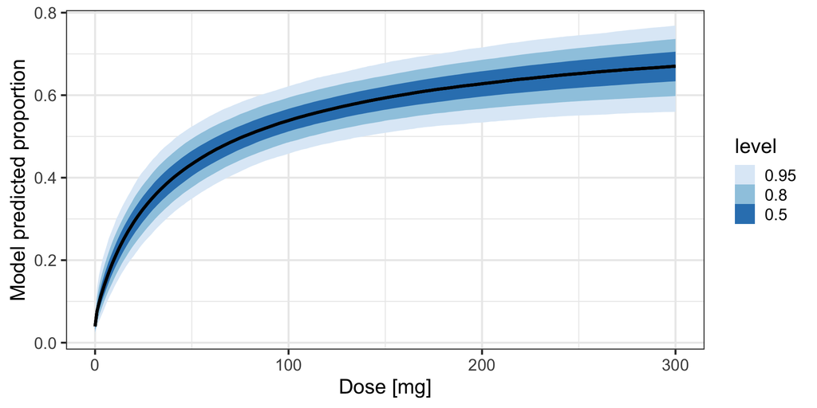

```r
tibble(dose = seq(0, 300, 1), n=1) |>
  tidybayes::add_epred_rvars(brmfit1) |>
  ggplot(aes(x=dose, ydist=.epred)) +
  stat_lineribbon() +
  scale_fill_brewer(palette="Blues") +
  ylab("Model predicted proportion") +
  xlab("Dose [mg]")
```

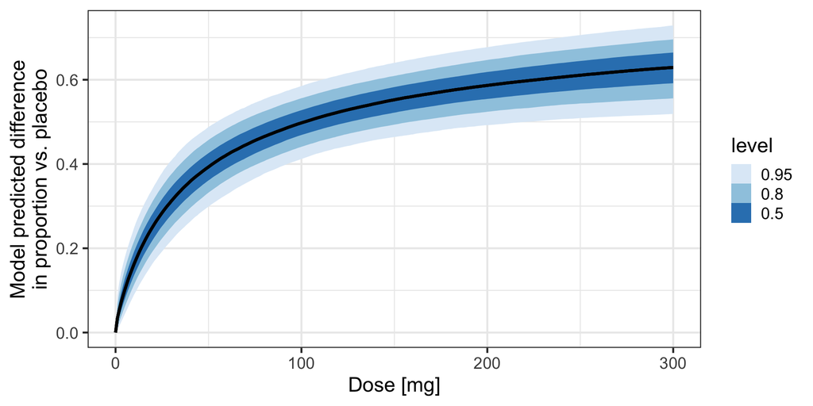

```r
pr <- tibble(dose = seq(0, 300, 1), n=1) |>
    tidybayes::add_epred_rvars(brmfit1)

left_join(pr, filter(pr, dose == 0)|>
              dplyr::select(-dose) |>
              rename(.pbo=.epred),
          by="n") |>
    mutate(diff = .epred - .pbo) |>
    ggplot(aes(x=dose, ydist=diff)) +
    stat_lineribbon() +
    scale_fill_brewer(palette="Blues") +
    ylab("Model predicted difference\nin proportion vs. placebo") +
    xlab("Dose [mg]")
```

## Exercise 1: linpred vs. epred vs. predicted

`tidybayes` offers three ways to get posterior draws for new data. They differ in *what* is predicted, here for a hypothetical arm of `n = 50` patients:

```r
tibble(dose = c(0, 50, 300), n = 50) |>
  add_linpred_rvars(brmfit1, value = "linpred") |>
  add_epred_rvars(brmfit1, value = "epred") |>
  add_predicted_rvars(brmfit1, value = "predicted")
```

```
# A tibble: 3 × 5
   dose     n       linpred        epred  predicted
  <dbl> <dbl>    <rvar[1d]>   <rvar[1d]> <rvar[1d]>
1     0    50  -3.20 ± 0.33   2.1 ± 0.66    2 ± 1.5
2    50    50  -0.27 ± 0.19  21.7 ± 2.27   22 ± 4.2
3   300    50   0.71 ± 0.25  33.4 ± 2.67   33 ± 4.3
```

- `add_linpred_rvars()` (`posterior_linpred()`): the non-linear predictor $\eta(d) = E_0 + E_{\max}\, d^h / (d^h + \mathrm{ED}_{50}^h)$ on the *link* scale, here log-odds. Does not depend on `n`.
- `add_epred_rvars()` (`posterior_epred()`): the *expected* outcome, $E[y \mid d] = n \cdot \text{logit}^{-1}(\eta(d))$. It reflects parameter uncertainty only; with `n = 1` it is the responder proportion, which is why we used `n = 1` above.
- `add_predicted_rvars()` (`posterior_predict()`): *simulated new outcomes*, $y \sim \text{Binomial}(n, \text{logit}^{-1}(\eta(d)))$, i.e. parameter uncertainty plus sampling noise. Hence integer counts and the widest intervals; use it for posterior predictive checks or to predict the result of a future trial.

For families with further distributional parameters, such as the Gaussian `sigma` in Exercise 2a, `add_linpred_rvars(dpar = TRUE)` returns these per draw as well.

## Exercise 1: logistic E<sub>max</sub> vs. BLRM

Our model puts the E<sub>max</sub> curve **inside** the logit:

$$\text{logit}(p(d)) = E_0 + E_{\max} \frac{d^h}{d^h + \mathrm{ED}_{50}^h}$$

- $p(0) = \text{logit}^{-1}(E_0) > 0$: placebo responders
- $p(\infty) = \text{logit}^{-1}(E_0 + E_{\max}) < 1$: not every patient responds

The BLRM from the lecture is the sigmoid E<sub>max</sub> model on the **probability scale** with $E_0 = 0$ and $E_{\max} = 1$. It forces $\pi(0) = 0$ and $\pi(\infty) = 1$: natural for toxicity, but not for efficacy.

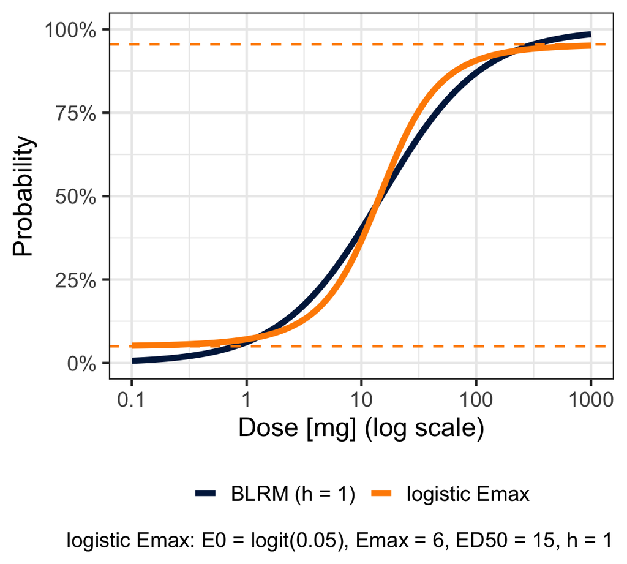

## Exercise 2a: interval censoring, solution

```r
model2 <- bf( logAVAL | cens(censored, logAVALnext) ~ E0 + Emax * dose^h/(dose^h + ED50^h),
              family = gaussian(),
              nlf(h ~ exp(logh)), nlf(ED50 ~ exp(logED50)),
              E0 ~ 1, logED50 ~ 1, logh ~ 1, Emax ~ 1,
              nl=TRUE )

priors2 <- prior(normal(0, 5), nlpar=E0) +             # centered on 1 mg, very uncertain
           prior(normal(0, log(4)/1.96), nlpar=logh) + # same shape as for binomial outcome
           prior(normal(0, 6.5), nlpar=Emax) +         # >= 1000 mg plausible, 300000 conceivable
           prior(normal(2.7, 2.5), nlpar=logED50) +    # ED50 as for binomial outcome
           prior(lognormal(5, 10), class=sigma)        # new: between-patient SD on log scale

brmfit2 <- brm(
  formula = model2,
  prior = priors2,
  data = peanut_cens,
  refresh=0
  )
```

```
Running MCMC with 4 parallel chains...
```

```
Chain 1 finished in 4.2 seconds.
Chain 4 finished in 4.2 seconds.
Chain 2 finished in 4.4 seconds.
Chain 3 finished in 5.1 seconds.

All 4 chains finished successfully.
Mean chain execution time: 4.5 seconds.
Total execution time: 5.3 seconds.
```

```r
summary(brmfit2)
```

```
 Family: gaussian
  Links: mu = identity
Formula: logAVAL | cens(censored, logAVALnext) ~ E0 + Emax * dose^h/(dose^h + ED50^h)
         h ~ exp(logh)
         ED50 ~ exp(logED50)
         E0 ~ 1
         logED50 ~ 1
         logh ~ 1
         Emax ~ 1
   Data: peanut_cens (Number of observations: 300)
  Draws: 4 chains, each with iter = 2000; warmup = 1000; thin = 1;
         total post-warmup draws = 4000

Regression Coefficients:
                  Estimate Est.Error l-95% CI u-95% CI Rhat Bulk_ESS Tail_ESS
E0_Intercept          0.83      0.43    -0.02     1.65 1.00     2111     2354
logED50_Intercept     3.16      0.94     1.86     5.61 1.00     1383     1207
logh_Intercept       -0.56      0.31    -1.15     0.08 1.00     1306     1869
Emax_Intercept        7.99      1.81     5.58    12.58 1.00     1206     1257

Further Distributional Parameters:
      Estimate Est.Error l-95% CI u-95% CI Rhat Bulk_ESS Tail_ESS
sigma     2.64      0.15     2.36     2.94 1.00     2274     2139

Draws were sampled using sample(hmc). For each parameter, Bulk_ESS
and Tail_ESS are effective sample size measures, and Rhat is the potential
scale reduction factor on split chains (at convergence, Rhat = 1).
```

## Exercise 2a: reading priors and posterior

The priors, translated back to milligrams:

- `E0 ~ N(0, 5)`: placebo median tolerated amount centered on $e^0 = 1$ mg, with a 95% prior interval of $e^{\pm 9.8}$, i.e. 0.00006 to 18,000 mg: deliberately vague.
- `Emax ~ N(0, 6.5)`: a one-SD effect multiplies the tolerated amount by $e^{6.5} \approx 665$, moving a placebo patient from about 1 mg to beyond 600 mg; two SD ($e^{13}$) remain conceivable.
- `logh`, `logED50`: unchanged, because the *shape* of the dose response does not depend on how we measure the outcome.
- `sigma ~ lognormal(5, 10)`: intended as “allow a large SD on the log scale”. We revisit this choice at the end.

```r
as_draws_df(brmfit2) |>
  mutate_variables(median_pbo_mg = exp(b_E0_Intercept),
                   max_fold_increase = exp(b_Emax_Intercept),
                   ED50_mg = exp(b_logED50_Intercept)) |>
  subset_draws(variable = c("median_pbo_mg", "max_fold_increase", "ED50_mg", "sigma")) |>
  summarise_draws(median, ~quantile2(.x, probs = c(0.025, 0.975)))
```

```
# A tibble: 4 × 4
  variable           median    q2.5     q97.5
  <chr>               <dbl>   <dbl>     <dbl>
1 median_pbo_mg        2.30   0.982      5.21
2 max_fold_increase 2021.   266.    291245.
3 ED50_mg             19.1    6.43     272.
4 sigma                2.63   2.36       2.94
```

`Emax` is the effect at an *infinitely* high dose, far beyond the 300 mg tested, so the data constrain it only weakly: note the long upper tail of `max_fold_increase`.

## Exercise 2b: ordinal regression, solution

```r
# no E0: the thresholds (Intercept[1], ..., Intercept[6]) describe the placebo outcome
model3 <- bf(AVAL ~ Emax * dose^h/(dose^h + ED50^h),
             family = cumulative(link = "logit", threshold = "flexible"),
             nlf(h ~ exp(logh)),
             nlf(ED50 ~ exp(logED50)),
             logED50 ~ 1,
             logh ~ 1,
             Emax ~ 1,
             nl=TRUE)

priors3 <- prior(normal(0, log(4)/1.96), nlpar=logh) +
           prior(normal(0, 6), nlpar=Emax) +
           prior(normal(2.7, 2.5), nlpar=logED50) +
           prior(student_t(3, 0, 2.5), class=Intercept) +
           prior(student_t(3, -0.2, 1), class=Intercept, coef=1) +
           prior(student_t(3, 2.197, 1), class=Intercept, coef=5)

brmfit3 <- brm(
  formula = model3,
  prior = priors3,
  data = mutate(peanut, AVAL = ordered(AVAL)),
  refresh=0
  )
```

```
Running MCMC with 4 parallel chains...

Chain 1 finished in 10.1 seconds.
Chain 3 finished in 10.5 seconds.
Chain 4 finished in 10.8 seconds.
Chain 2 finished in 11.1 seconds.

All 4 chains finished successfully.
Mean chain execution time: 10.6 seconds.
Total execution time: 11.3 seconds.
```

```r
summary(brmfit3)
```

```
 Family: cumulative
  Links: mu = logit
Formula: AVAL ~ Emax * dose^h/(dose^h + ED50^h)
         h ~ exp(logh)
         ED50 ~ exp(logED50)
         logED50 ~ 1
         logh ~ 1
         Emax ~ 1
   Data: mutate(peanut, AVAL = ordered(AVAL)) (Number of observations: 300)
  Draws: 4 chains, each with iter = 2000; warmup = 1000; thin = 1;
         total post-warmup draws = 4000

Regression Coefficients:
                  Estimate Est.Error l-95% CI u-95% CI Rhat Bulk_ESS Tail_ESS
Intercept[1]          0.05      0.25    -0.43     0.57 1.00     3574     2409
Intercept[2]          1.01      0.27     0.50     1.58 1.00     4195     2469
Intercept[3]          1.74      0.29     1.19     2.33 1.00     4024     2637
Intercept[4]          2.29      0.30     1.73     2.89 1.00     3930     2519
Intercept[5]          3.04      0.30     2.47     3.65 1.00     4137     2731
Intercept[6]          4.03      0.33     3.40     4.69 1.00     4124     2825
logED50_Intercept     3.82      1.09     2.23     6.38 1.00     1304     1171
logh_Intercept       -0.60      0.30    -1.13     0.00 1.00     1498     2102
Emax_Intercept        5.45      1.50     3.47     9.20 1.00     1225     1119

Further Distributional Parameters:
     Estimate Est.Error l-95% CI u-95% CI Rhat Bulk_ESS Tail_ESS
disc     1.00      0.00     1.00     1.00   NA       NA       NA

Draws were sampled using sample(hmc). For each parameter, Bulk_ESS
and Tail_ESS are effective sample size measures, and Rhat is the potential
scale reduction factor on split chains (at convergence, Rhat = 1).
```

## Exercise 2b: reading priors and posterior

- `logh`, `logED50`: unchanged (shape of the dose response).
- `Emax ~ N(0, 6)`: under proportional odds `Emax` is the log-odds ratio for *every* cut-point, including $\geq$ 600 mg, so the prior from Exercise 1 carries over directly.
- `Intercept ~ student_t(3, 0, 2.5)`: weakly informative default for all thresholds; the ordering constraint does the rest.
- `Intercept[1] ~ student_t(3, -0.2, 1)`: $\text{logit}^{-1}(-0.2) \approx 0.45$, i.e. about 45% of placebo patients are expected to fail at the first 3 mg step.
- `Intercept[5] ~ student_t(3, 2.197, 1)`: $\text{logit}^{-1}(2.197) = 0.9$, i.e. 10% placebo responders, whereas Exercise 1 assumed 5%. We revisit this at the end.

Predicted category probabilities on placebo, and the observed proportions:

```r
tibble(dose = 0) |> add_epred_rvars(brmfit3) |> pull(.epred)
```

```
rvar<4000>[1,7] mean ± sd:
     0               3               10              100             300             600             1000
[1,] 0.513 ± 0.0624  0.218 ± 0.0339  0.117 ± 0.0244  0.058 ± 0.0149  0.048 ± 0.0135  0.029 ± 0.0087  0.018 ± 0.0060
```

```r
peanut |> filter(dose == 0) |> count(AVAL) |> mutate(observed = n / sum(n)) |> kable(digits = 2)
```

| AVAL | n | observed |
| --- | --- | --- |
| 0 | 28 | 0.56 |
| 3 | 10 | 0.20 |
| 10 | 6 | 0.12 |
| 100 | 3 | 0.06 |
| 300 | 3 | 0.06 |

## Exercise 2b: posterior predictive check

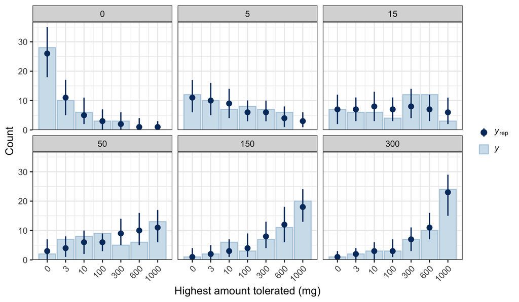

```r
pp_check(brmfit3, type = "bars_grouped", group = "dose", ndraws = 200) +
  scale_x_continuous("Highest amount tolerated (mg)", breaks = 1:7,
                     labels = levels(ordered(peanut$AVAL))) +
  theme(axis.text.x = element_text(angle = 45, hjust = 1))
```

- Bars: observed counts per category; points and intervals: posterior predictive distribution. Systematic misfit at particular doses or categories would indicate that proportional odds is violated.
- `group` must be a variable the model uses (`dose`), not `TRT01P`.
- For the censored model 2a, `pp_check()` would be misleading: it compares simulated continuous $\log T$ with the recorded interval bounds. One would first have to bin the predictions into the challenge categories.

## Comparing the three models

All three models predict the primary endpoint, $\Pr(T \geq 600\text{ mg})$: the binomial model directly, the censored model as $1 - \Phi\big((\log 600 - \mu(d)) / \sigma\big)$, and the ordinal model as the sum of the probabilities of the categories 600 and 1000 mg.

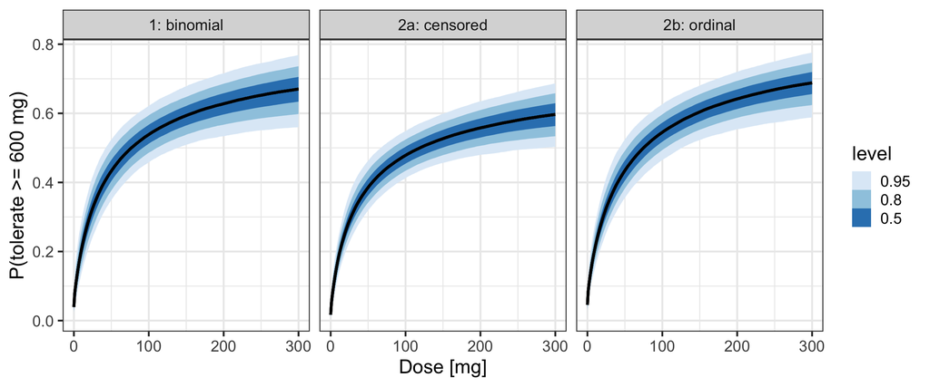

```r
dose_grid <- tibble(dose = seq(0, 300, 1), n = 1)

p600 <- bind_rows(
  "1: binomial" = add_epred_rvars(dose_grid, brmfit1) |> transmute(dose, p600 = .epred),
  "2a: censored" = add_linpred_rvars(dose_grid, brmfit2, dpar = TRUE) |>
    transmute(dose, p600 = 1 - rdo(pnorm((log(600) - mu) / sigma))),
  "2b: ordinal" = add_epred_rvars(dose_grid, brmfit3) |>
    transmute(dose, p600 = .epred[, "600"] + .epred[, "1000"]),
  .id = "model")

ggplot(p600, aes(x = dose, ydist = p600)) +
  stat_lineribbon() +
  scale_fill_brewer(palette = "Blues") +
  facet_wrap(~model, nrow = 1) +
  ylab("P(tolerate >= 600 mg)") +
  xlab("Dose [mg]")
```

```r
p600 |>
  filter(dose %in% c(0, 50, 300)) |>
  mutate(mean = mean(p600), sd = sd(p600)) |>
  select(dose, model, mean, sd) |>
  arrange(dose, model) |>
  kable(digits = 3)
```

| dose | model | mean | sd |
| --- | --- | --- | --- |
| 0 | 1: binomial | 0.0410 | 0.01316 |
| 0 | 2a: censored | 0.0187 | 0.00859 |
| 0 | 2b: ordinal | 0.0474 | 0.01365 |
| 50 | 1: binomial | 0.4343 | 0.04532 |
| 50 | 2a: censored | 0.3870 | 0.03657 |
| 50 | 2b: ordinal | 0.4356 | 0.04315 |
| 300 | 1: binomial | 0.6686 | 0.05349 |
| 300 | 2a: censored | 0.5963 | 0.04780 |
| 300 | 2b: ordinal | 0.6864 | 0.04784 |

`dpar = TRUE` returns all *distributional parameters* (here `mu` and `sigma`) per dose as `rvar`s; `rdo()` evaluates any R expression draw by draw.

## Comparing the three models: take-aways

- All models agree on the overall picture: responder rates rise steeply up to about 50 mg and flatten afterwards.
- The ordinal model reproduces the binomial dose response with somewhat narrower intervals: it uses all 7 outcome levels, at the price of the proportional odds assumption.
- The censored model predicts fewer responders at high doses, reflecting the stronger assumption that $\log T$ is normally distributed.
- “More efficient” analyses buy precision with assumptions. Check them, e.g. with posterior predictive checks, before trusting the narrower intervals, and pre-specify the primary analysis.

## Discussion: the `sigma` prior (2a)

`sigma ~ lognormal(5, 10)` was meant to “allow a large SD on the log scale”. What does it actually say?

```r
qlnorm(c(0.05, 0.5, 0.95), meanlog = 5, sdlog = 10)
```

```
[1] 1.07e-05 1.48e+02 2.07e+09
```

```r
plnorm(10, meanlog = 5, sdlog = 10, lower.tail = FALSE)
```

```
[1] 0.606
```

Its median is an SD of about 148 on the log scale, and more than half of its mass lies above 10. Yet already $\sigma = 3$ means that the middle 95% of patients on one dose span a factor of $e^{2 \cdot 1.96 \cdot 3} \approx 10^5$. A half-normal prior with scale 3 (`normal(0, 3)`; `brms` bounds `sigma` at 0) puts 95% of its mass below 5.9 and is still generous:

```r
priors2_new <- priors2[priors2$class != "sigma", ] + prior(normal(0, 3), class = sigma)
brmfit2_new <- update(brmfit2, prior = priors2_new, refresh = 0)
```

```
Running MCMC with 4 parallel chains...
```

```
Chain 1 finished in 4.1 seconds.
Chain 2 finished in 4.1 seconds.
Chain 3 finished in 4.4 seconds.
Chain 4 finished in 4.3 seconds.

All 4 chains finished successfully.
Mean chain execution time: 4.2 seconds.
Total execution time: 4.6 seconds.
```

```r
compare_fits <- function(fits, variable) {
  lapply(fits, \(fit) summarise_draws(as_draws_df(fit, variable = variable),
                                      mean, sd, ~quantile2(.x, probs = c(0.025, 0.975)))) |>
    bind_rows(.id = "fit") |>
    arrange(variable)
}

compare_fits(list(original = brmfit2, `half-normal` = brmfit2_new),
             c("b_E0_Intercept", "b_Emax_Intercept", "sigma")) |>
  kable(digits = 2)
```

| fit | variable | mean | sd | q2.5 | q97.5 |
| --- | --- | --- | --- | --- | --- |
| original | b_E0_Intercept | 0.83 | 0.43 | -0.02 | 1.65 |
| half-normal | b_E0_Intercept | 0.81 | 0.42 | -0.02 | 1.64 |
| original | b_Emax_Intercept | 7.99 | 1.81 | 5.58 | 12.58 |
| half-normal | b_Emax_Intercept | 8.11 | 1.79 | 5.73 | 12.71 |
| original | sigma | 2.64 | 0.15 | 2.36 | 2.94 |
| half-normal | sigma | 2.64 | 0.16 | 2.37 | 2.97 |

The posterior hardly changes: with 300 patients the data dominate `sigma`. The original prior was harmless *here*, but would not be in a small trial or a prior predictive check. Always translate priors back to the outcome scale.

## Discussion: the threshold prior (2b)

Exercise 1 assumed about 5% placebo responders (`E0 ~ N(-2.944, 0.38)` on the logit scale), but the ordinal model centered `Intercept[5]` on 10%. The same belief about the same trial should give the same prior, i.e. $\theta_5$ centered on $\text{logit}(0.95) = 2.944$:

```r
priors3_new <- priors3[!(priors3$class == "Intercept" & priors3$coef == "5"), ] +
  prior(student_t(3, 2.944, 1), class = Intercept, coef = 5)
brmfit3_new <- update(brmfit3, prior = priors3_new, refresh = 0)
```

```
Running MCMC with 4 parallel chains...

Chain 3 finished in 9.7 seconds.
Chain 2 finished in 9.7 seconds.
Chain 4 finished in 11.3 seconds.
Chain 1 finished in 12.1 seconds.

All 4 chains finished successfully.
Mean chain execution time: 10.7 seconds.
Total execution time: 12.2 seconds.
```

```r
compare_fits(list(original = brmfit3, `5% responders` = brmfit3_new),
             c("b_Intercept[5]", "b_Emax_Intercept")) |>
  kable(digits = 2)
```

| fit | variable | mean | sd | q2.5 | q97.5 |
| --- | --- | --- | --- | --- | --- |
| original | b_Emax_Intercept | 5.45 | 1.50 | 3.47 | 9.20 |
| 5% responders | b_Emax_Intercept | 5.48 | 1.47 | 3.62 | 9.35 |
| original | b_Intercept[5] | 3.04 | 0.30 | 2.47 | 3.65 |
| 5% responders | b_Intercept[5] | 3.10 | 0.30 | 2.52 | 3.70 |

Again little changes: the 50 placebo patients, and through proportional odds all other patients, inform the thresholds well. Still, keep priors consistent across alternative analyses of the same trial; otherwise differences between the analyses may be driven by the priors rather than by the models.